# Exercise set Week 2

# Exercise set 2

# Exercise 1: Exploratory data analysis

Here we continue to study the Titanic data set from Week 1 (Exercise 1).

We use the preprocessed data during Week 1. The columns Name and Ticket are excluded from dataset because they are not related to the analysis. I also remove the column PassengerId from the data set since it is not useful for the further statistical analysis.

```r
library(dplyr)
titanic <- read.csv(file="testOut.csv",header=TRUE,sep=",")
keep <- c("Survived", "Pclass", "Sex", "Age", "SibSp", "Parch", "Fare", "Cabin", "Embarked")
titanic <- select(titanic, one_of(keep))
```

# 1.1 Add average values at the last row of the dataframe

```
#initially set the ast row to be the same as row=890
data.loc[892,:] = data.loc[890,:]
col_names= ["Survived","Sex", "Embarked", "Cabin", "PassengerId", "Pclass", "Age", "SibSp", "Parch", "Fare"]
print("Average Joe:")

for val in col_names:
    #for categorical columns take mode
 if (val == "Sex" or val == "Embarked" or val == "Cabin" ):
     data[892,val] = data[val].mode()
 #for numerical columns take median
 else:
     data[892,val] = data[val].median()

 #dataA = concat(data, averageJoe)
 data.tail(n=5)
```

Last row represent the “Average Joe” on board of the ship. who is male at age about 30 and did not survived. The values of other variables at the last row: Pclass = 3, SibSp = 0, Parch = 0, Fare = 14.45, Cabin = 75, Embarked = 2.

# 1.2 Take subsets SurvivorJane and NonsurvivorJoe

Subset of survived females is formed as:

```
Female= data["Sex"] > 0
Female.head(5)
Survived = data["Survived"] >0
Survived.head(5)
SurvivorJane = data[Female & Survived]
```

Subsed of non-survived males is taken as:

```
Male= data["Sex"] < 1
Male.head(5)
NonSurvivor = data["Survived"] < 1
NonSurvivorJoe = data[Male & NonSurvivor]
```

# 1.3 Exploratory analysis of the subsets SurvivorJane and NonsurvivorJoe

I remove the column PassengerId from both subsests as it does not provide useful statistical information.

```r
SurvivorJane <- read.csv(file="SurvivorJane.csv",header=TRUE,sep=",")
#remove PassingerID
keep <- c("Survived", "Pclass", "Sex", "Age", "SibSp", "Parch", "Fare", "Cabin", "Embarked")
SurvivorJane <- select(SurvivorJane, one_of(keep))
dim(SurvivorJane)
```

```
## [1] 233   9
```

```r
summary(SurvivorJane)
```

```
##     Survived     Pclass           Sex         Age            SibSp
##  Min.   :1   Min.   :1.000   Min.   :0   Min.   : 0.75   Min.   :0.000
##  1st Qu.:1   1st Qu.:1.000   1st Qu.:0   1st Qu.:22.00   1st Qu.:0.000
##  Median :1   Median :2.000   Median :0   Median :29.70   Median :0.000
##  Mean   :1   Mean   :1.918   Mean   :0   Mean   :28.98   Mean   :0.515
##  3rd Qu.:1   3rd Qu.:3.000   3rd Qu.:0   3rd Qu.:35.00   3rd Qu.:1.000
##  Max.   :1   Max.   :3.000   Max.   :0   Max.   :63.00   Max.   :4.000
##      Parch            Fare             Cabin           Embarked
##  Min.   :0.000   Min.   :  7.225   Min.   :  2.00   Min.   :0.000
##  1st Qu.:0.000   1st Qu.: 13.000   1st Qu.: 75.00   1st Qu.:0.000
##  Median :0.000   Median : 26.000   Median : 75.00   Median :2.000
##  Mean   :0.515   Mean   : 51.939   Mean   : 75.98   Mean   :1.335
##  3rd Qu.:1.000   3rd Qu.: 76.292   3rd Qu.: 75.00   3rd Qu.:2.000
##  Max.   :5.000   Max.   :512.329   Max.   :145.00   Max.   :2.000
```

```r
NonSurvivorJoe <- read.csv(file="NonSurvivorJoe.csv",header=TRUE,sep=",")
#remove PassingerID
NonSurvivorJoe <- select(NonSurvivorJoe, one_of(keep))
dim(NonSurvivorJoe)
```

```
## [1] 468   9
```

```r
summary(NonSurvivorJoe)
```

```
##     Survived     Pclass           Sex         Age            SibSp
##  Min.   :0   Min.   :1.000   Min.   :1   Min.   : 1.00   Min.   :0.0000
##  1st Qu.:0   1st Qu.:2.000   1st Qu.:1   1st Qu.:24.00   1st Qu.:0.0000
##  Median :0   Median :3.000   Median :1   Median :29.70   Median :0.0000
##  Mean   :0   Mean   :2.476   Mean   :1   Mean   :31.18   Mean   :0.4402
##  3rd Qu.:0   3rd Qu.:3.000   3rd Qu.:1   3rd Qu.:36.00   3rd Qu.:0.0000
##  Max.   :0   Max.   :3.000   Max.   :1   Max.   :74.00   Max.   :8.0000
##      Parch             Fare             Cabin           Embarked
##  Min.   :0.0000   Min.   :  0.000   Min.   :  0.00   Min.   :0.000
##  1st Qu.:0.0000   1st Qu.:  7.796   1st Qu.: 75.00   1st Qu.:2.000
##  Median :0.0000   Median :  9.417   Median : 75.00   Median :2.000
##  Mean   :0.2073   Mean   : 21.961   Mean   : 74.53   Mean   :1.637
##  3rd Qu.:0.0000   3rd Qu.: 26.000   3rd Qu.: 75.00   3rd Qu.:2.000
##  Max.   :5.0000   Max.   :263.000   Max.   :146.00   Max.   :2.000
```

First look the distributions of all variables of the whole data set. Different colors are according the Sex column.

```r
library(GGally)
```

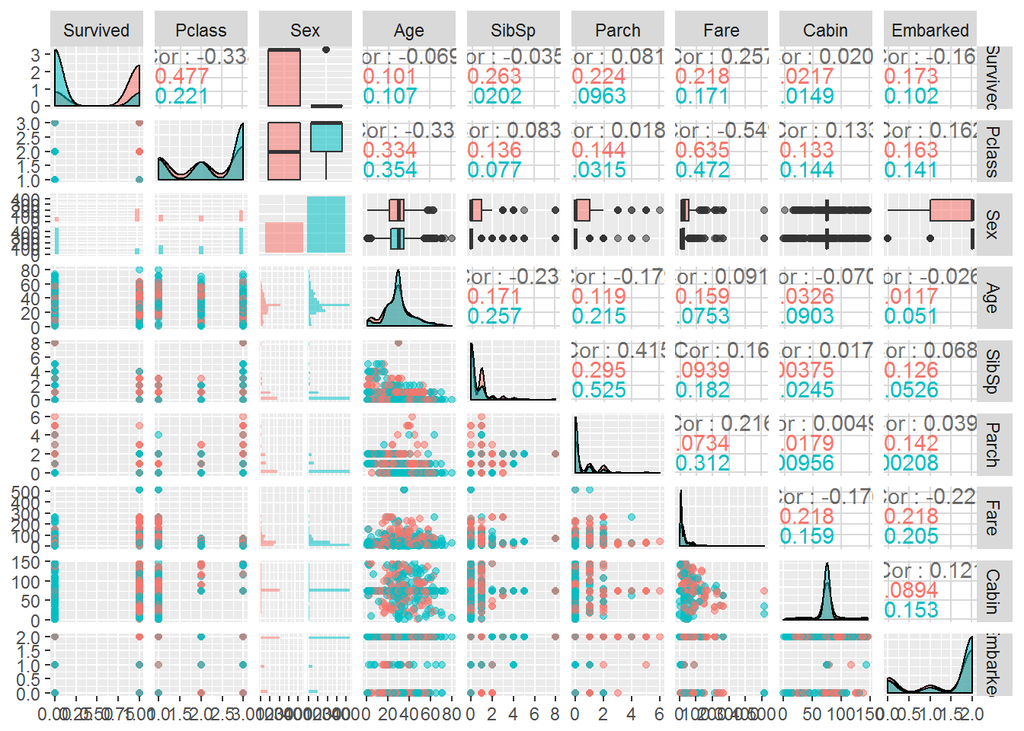

```r
library(ggplot2)
titanic$Sex <- as.factor(titanic$Sex)
pTitanic <- ggpairs(titanic, mapping = aes(col=Sex, alpha=0.3), lower = list(combo = wrap("facethist", bins = 20)))
pTitanic
```

Another presentation of correlation plot:

```r
#another presentation of correlation matrix
titanic$Sex <- as.numeric(titanic$Sex)
titanic$Survived <- as.numeric(titanic$Survived)
cor_matrix<-cor(titanic) %>% round(digits =2)
cor_matrix
```

```
##          Survived Pclass   Sex   Age SibSp Parch  Fare Cabin Embarked
## Survived     1.00  -0.34 -0.54 -0.07 -0.04  0.08  0.26  0.02    -0.17
## Pclass      -0.34   1.00  0.13 -0.33  0.08  0.02 -0.55  0.13     0.16
## Sex         -0.54   0.13  1.00  0.08 -0.11 -0.25 -0.18 -0.04     0.11
## Age         -0.07  -0.33  0.08  1.00 -0.23 -0.18  0.09 -0.07    -0.03
## SibSp       -0.04   0.08 -0.11 -0.23  1.00  0.41  0.16  0.02     0.07
## Parch        0.08   0.02 -0.25 -0.18  0.41  1.00  0.22  0.00     0.04
## Fare         0.26  -0.55 -0.18  0.09  0.16  0.22  1.00 -0.18    -0.22
## Cabin        0.02   0.13 -0.04 -0.07  0.02  0.00 -0.18  1.00     0.12
## Embarked    -0.17   0.16  0.11 -0.03  0.07  0.04 -0.22  0.12     1.00
```

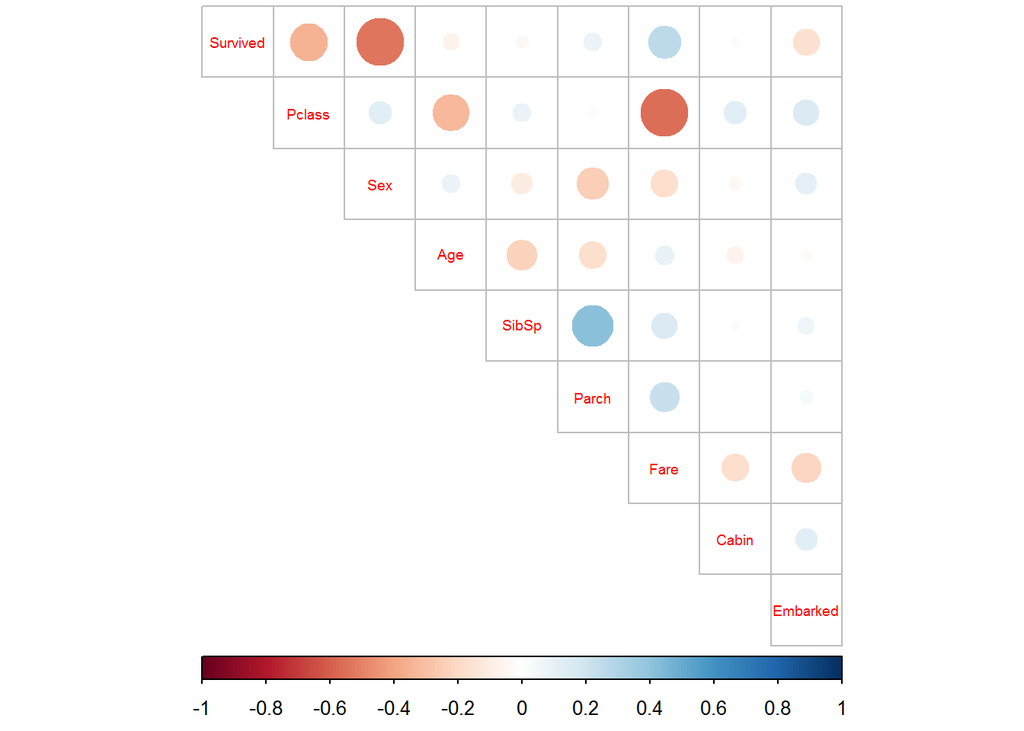

```r
library(corrplot)
corrplot(cor_matrix, method="circle", type = "upper", cl.pos = "b", tl.pos = "d", tl.cex = 0.6)
```

The correlation matrix suggests a high negative correlation between survived and Sex, and Pclass and Fare.

The distributions of the variables in *survivalJane* subgroup:

[output not shown]

[output cut: 115 more lines]

[output not shown]

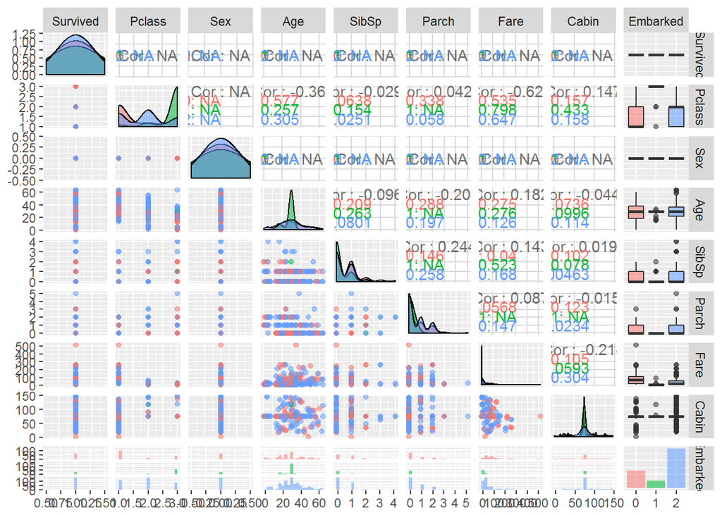

```r
SurvivorJane$Embarked <- as.factor(SurvivorJane$Embarked)
pJane <- ggpairs(SurvivorJane, mapping = aes(col=Embarked, alpha=0.3), lower = list(combo = wrap("facethist", bins = 20)))
pJane
```

Correlation matrix of this subset suggests high negative correlation between Pclass and Fare:

```r
SurvivorJane$Embarked <- as.numeric(SurvivorJane$Embarked)
cor_matrix<-cor(SurvivorJane) %>% round(digits =2)
cor_matrix
```

```
##          Survived Pclass Sex   Age SibSp Parch  Fare Cabin Embarked
## Survived        1     NA  NA    NA    NA    NA    NA    NA       NA
## Pclass         NA   1.00  NA -0.37 -0.03  0.04 -0.63  0.15     0.11
## Sex            NA     NA   1    NA    NA    NA    NA    NA       NA
## Age            NA  -0.37  NA  1.00 -0.10 -0.20  0.18 -0.04     0.02
## SibSp          NA  -0.03  NA -0.10  1.00  0.24  0.14  0.02     0.01
## Parch          NA   0.04  NA -0.20  0.24  1.00  0.09 -0.02     0.11
## Fare           NA  -0.63  NA  0.18  0.14  0.09  1.00 -0.22    -0.23
## Cabin          NA   0.15  NA -0.04  0.02 -0.02 -0.22  1.00     0.09
## Embarked       NA   0.11  NA  0.02  0.01  0.11 -0.23  0.09     1.00
```

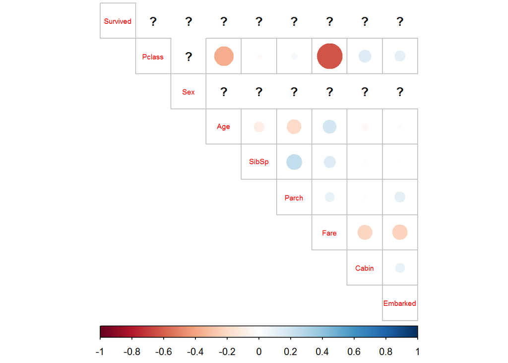

```r
corrplot(cor_matrix, method="circle", type = "upper", cl.pos = "b", tl.pos = "d", tl.cex = 0.6)
```

The distributions of the Cabin seems to be normal.

The distributions of the variables in *Non-survival Joe* subgroup:

[output not shown]

[output cut: 100 more lines]

[output not shown]

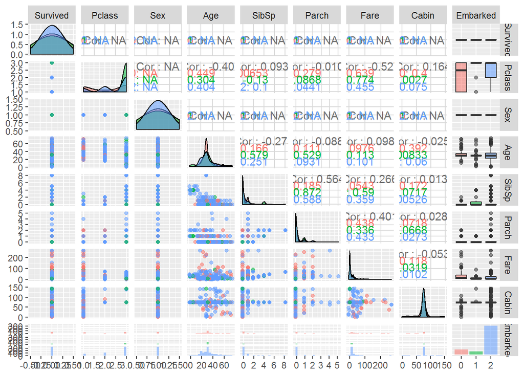

```r
NonSurvivorJoe$Embarked <- as.factor(NonSurvivorJoe$Embarked)
pJoe <- ggpairs(NonSurvivorJoe, mapping = aes(col=Embarked, alpha=0.3), lower = list(combo = wrap("facethist", bins = 20)))
pJoe
```

The correlation matrix of this subset shows high negative correlation between Pclass and Fare, and high positive corellation between SibSp and Parch.

```r
NonSurvivorJoe$Embarked <- as.numeric(NonSurvivorJoe$Embarked)
cor_matrix<-cor(NonSurvivorJoe) %>% round(digits =2)
cor_matrix
```

```
##          Survived Pclass Sex   Age SibSp Parch  Fare Cabin Embarked
## Survived        1     NA  NA    NA    NA    NA    NA    NA       NA
## Pclass         NA   1.00  NA -0.40  0.09 -0.01 -0.53  0.16     0.12
## Sex            NA     NA   1    NA    NA    NA    NA    NA       NA
## Age            NA  -0.40  NA  1.00 -0.28 -0.09  0.10 -0.03    -0.05
## SibSp          NA   0.09  NA -0.28  1.00  0.56  0.27  0.01     0.06
## Parch          NA  -0.01  NA -0.09  0.56  1.00  0.40  0.03     0.01
## Fare           NA  -0.53  NA  0.10  0.27  0.40  1.00 -0.05    -0.17
## Cabin          NA   0.16  NA -0.03  0.01  0.03 -0.05  1.00     0.12
## Embarked       NA   0.12  NA -0.05  0.06  0.01 -0.17  0.12     1.00
```

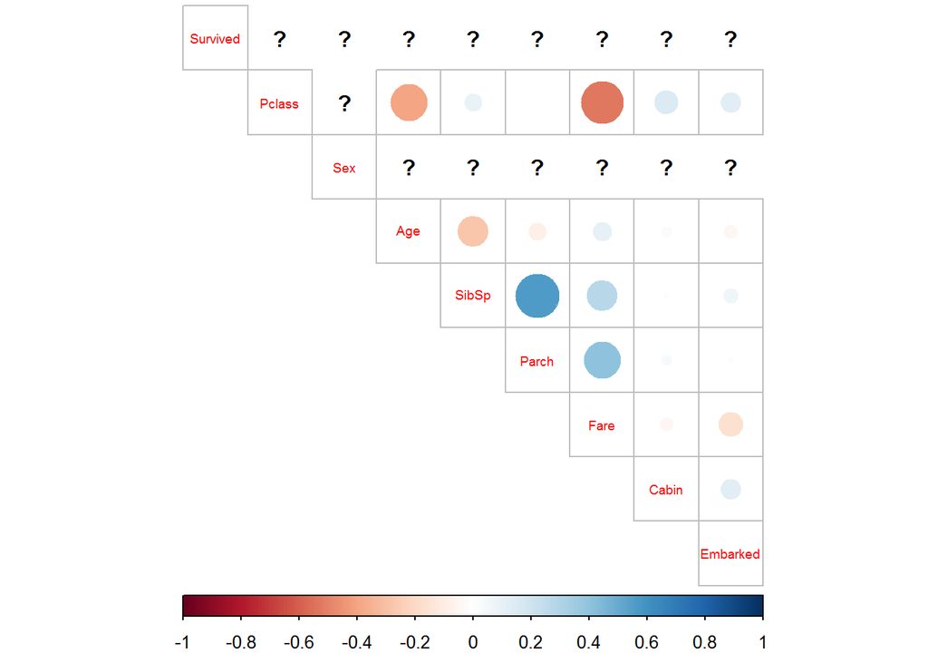

```r
corrplot(cor_matrix, method="circle", type = "upper", cl.pos = "b", tl.pos = "d", tl.cex = 0.6)
```